# International Collaboration in Animal Behavior:

An analysis of coauthorship in three leading journals

Trillo et al.

2025-07-09

## Methods

On June 12, 2025 we downloaded the bibliographic record of every article published in *Animal Behavior*, *Behavioral Ecology*, and *Behavioral Ecology & Sociobiology* that was indexed in the Web of Science *Core Collection*. These records were then processed and organized using the R package [`refsplitr`](https://docs.ropensci.org/refsplitr/index.html), with which we also disambiguated author names and visualized author locations and coauthorship networks.

Countries were assigned to Global Regions and National Income Categories using the [World Bank categories](https://datahelpdesk.worldbank.org/knowledgebase/articles/906519-world-bank-country-and-lending-groups).

Data and Code are available on [Github](https://github.com/BrunaLab/anim_behavior).

Fournier, A., M. E. Boone, F. R. Stevens, and E. M. Bruna. 2020. `refsplitr`: Author name disambiguation, author georeferencing, and mapping of coauthorship networks with Web of Science data. *Journal of Open Source Software*, 5(45), 2028, https://doi.org/10.21105/joss.02028

## Results

### Publications

#### 4. Publications per Journal (overall and with LatAm 1st Author)

| Journal | N | n_latam_first | percent_latam |
| --- | --- | --- | --- |
| animal behaviour | 12,471 | 249 | 2.0 |
| behavioral ecology | 4,836 | 98 | 2.0 |
| behavioral ecology and sociobiology | 6,487 | 233 | 3.6 |

### Authors

#### 1. Total No. of Authors *(all journals combined)*: N = 27,749

#### 2. In which countries are authors based?

Top N = 20 countries *(all journals combined)*

| Country (ISO code) | N | percent |
| --- | --- | --- |
| usa ( usa ) | 20,591 | 29.87 |
| uk ( gbr ) | 6,294 | 9.13 |
| canada ( can ) | 5,267 | 7.64 |
| germany ( deu ) | 4,207 | 6.10 |
| australia ( aus ) | 4,133 | 6.00 |
| united kingdom ( gbr ) | 3,422 | 4.96 |
| france ( fra ) | 2,998 | 4.35 |
| spain ( esp ) | 2,010 | 2.92 |
| sweden ( swe ) | 1,742 | 2.53 |
| netherlands ( nld ) | 1,585 | 2.30 |
| switzerland ( che ) | 1,579 | 2.29 |
| italy ( ita ) | 1,464 | 2.12 |
| japan ( jpn ) | 1,118 | 1.62 |
| finland ( fin ) | 1,101 | 1.60 |
| china ( chn ) | 1,058 | 1.53 |
| norway ( nor ) | 941 | 1.37 |
| south africa ( zaf ) | 744 | 1.08 |
| israel ( isr ) | 703 | 1.02 |
| brazil ( bra ) | 686 | 1.00 |
| belgium ( bel ) | 676 | 0.98 |

#### 3. In which region are authors based?

| region | N | percent |
| --- | --- | --- |
| europe & central asia | 31,477 | 45.67 |
| north america | 25,858 | 37.51 |
| east asia & pacific | 7,301 | 10.59 |
| latin america & caribbean | 2,133 | 3.09 |
| sub-saharan africa | 1,114 | 1.62 |
| middle east & north africa | 739 | 1.07 |
| south asia | 308 | 0.45 |

#### 4. What are the most commonly represented affiliations?

Top N = 20 Affiliations *(all journals combined)*

*Preliminary Results*: affiliations still require some cleaning

*Note: these are not unique authors (i.e., the same author at UF publishing 5 papers = UF x 5)*

| Affiliation | Country | N |
| --- | --- | --- |
| university of oxford | united kingdom | 270 |
| university of cambridge | united kingdom | 242 |
| university of california, davis | usa | 219 |
| university of bristol | united kingdom | 179 |
| cornell university | usa | 161 |
| university of toronto | canada | 137 |
| university of washington | usa | 135 |
| university of st andrews | united kingdom | 133 |
| cnrs centre national de la recherche scientifique | france | 124 |
| max-planck-institut für ornithologie | germany | 121 |
| lunds universitet | sweden | 118 |
| rijksuniversiteit groningen | netherlands | 118 |
| indiana university bloomington | usa | 113 |
| the university of edinburgh | united kingdom | 109 |
| queen’s university | canada | 105 |
| university of california, berkeley | usa | 105 |
| stockholms universitet | sweden | 103 |
| universität zürich | switzerland | 100 |
| university of wisconsin-madison | usa | 97 |
| the university of sheffield | united kingdom | 95 |

#### 4. No. of coauthors & No. of countries on author list by region of 1st author

| region | avg_n_authors | sd_n_authors | avg_n_countries | sd_n_countries |
| --- | --- | --- | --- | --- |
| east asia & pacific | 3.7 | 1.7 | 1.4 | 0.65 |
| europe & central asia | 3.6 | 1.8 | 1.4 | 0.69 |
| latin america & caribbean | 3.7 | 1.7 | 1.5 | 0.71 |
| middle east & north africa | 3.7 | 2.2 | 1.5 | 0.88 |
| north america | 3.1 | 1.5 | 1.2 | 0.47 |
| south asia | 3.1 | 1.3 | 1.1 | 0.31 |
| sub-saharan africa | 3.4 | 1.4 | 1.5 | 0.61 |

### Coauthorhsip Analysis *(Note: Only papers with >1 author)*

#### 1. Are all co-authors from the same global region as the 1st Author?

| first author based in… | all coauthors in same region | N | % |
| --- | --- | --- | --- |
| east asia & pacific | TRUE | 1419 | 70.18 |
| east asia & pacific | FALSE | 603 | 29.82 |
| europe & central asia | TRUE | 7396 | 85.46 |
| europe & central asia | FALSE | 1258 | 14.54 |
| latin america & caribbean | TRUE | 340 | 63.43 |
| latin america & caribbean | FALSE | 196 | 36.57 |
| middle east & north africa | TRUE | 145 | 66.82 |
| middle east & north africa | FALSE | 72 | 33.18 |
| north america | TRUE | 6833 | 88.49 |
| north america | FALSE | 889 | 11.51 |
| south asia | TRUE | 86 | 91.49 |
| south asia | FALSE | 8 | 8.51 |
| sub-saharan africa | TRUE | 121 | 57.89 |
| sub-saharan africa | FALSE | 88 | 42.11 |

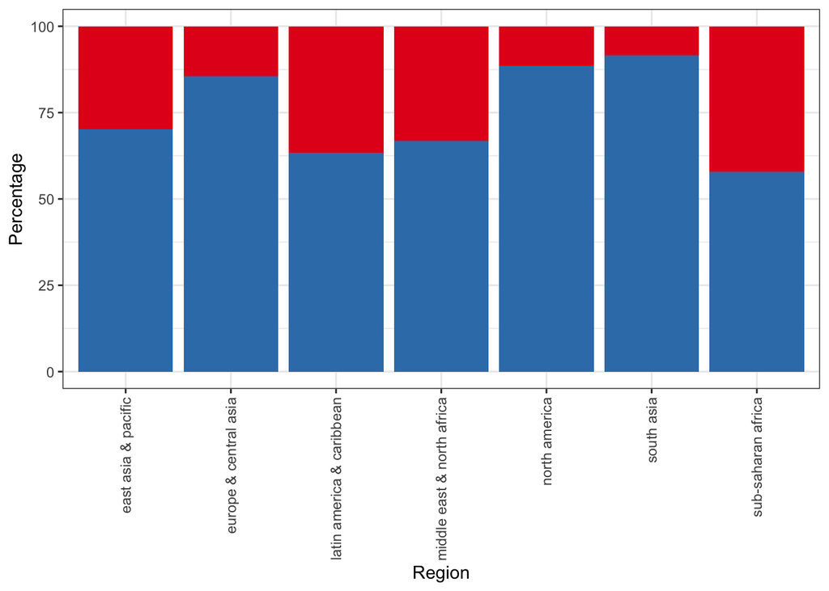

#### 2. Where are the coauthors of papers with 1st authors based in the Global North or South?

| first author based in… | all coauthors in same | N | % |
| --- | --- | --- | --- |
| north | FALSE | 1393 | 7.58 |
| north | TRUE | 16980 | 92.42 |
| south | FALSE | 426 | 33.23 |
| south | TRUE | 856 | 66.77 |

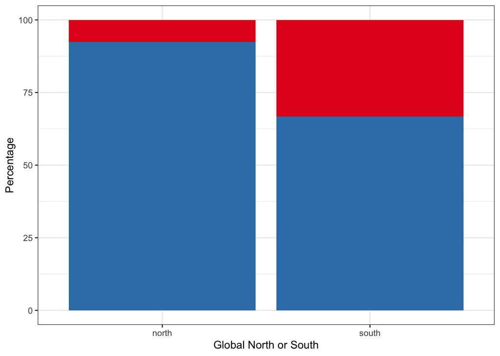

#### All author locations

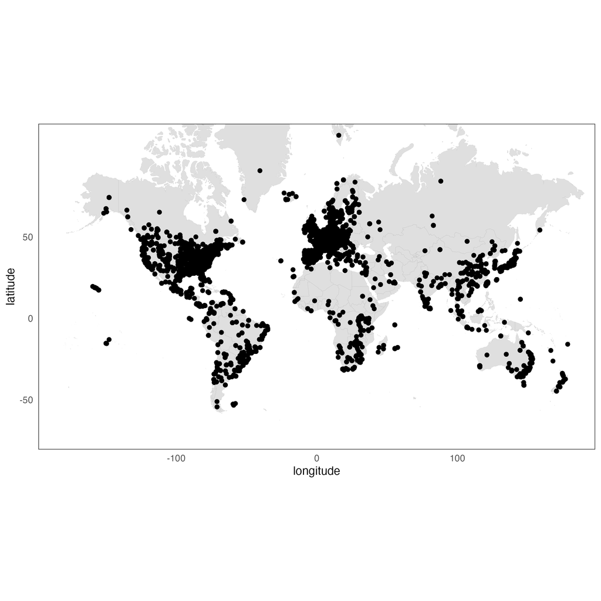

.

#### 1st Author Locations

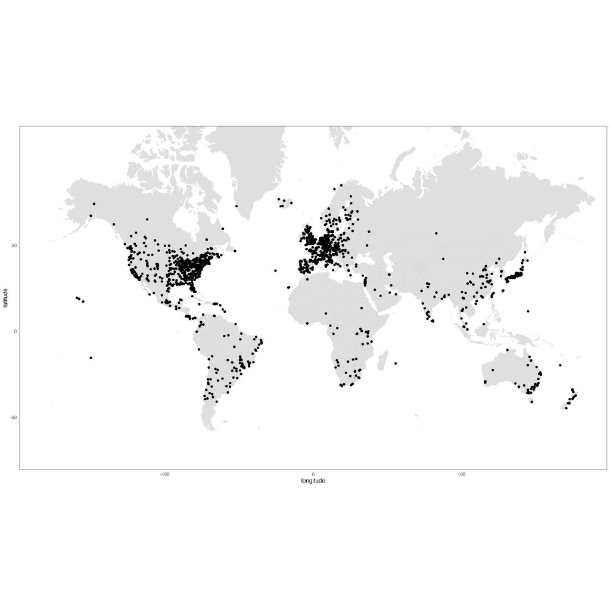

.

#### 1st Authors based in Latin America & Caribbean

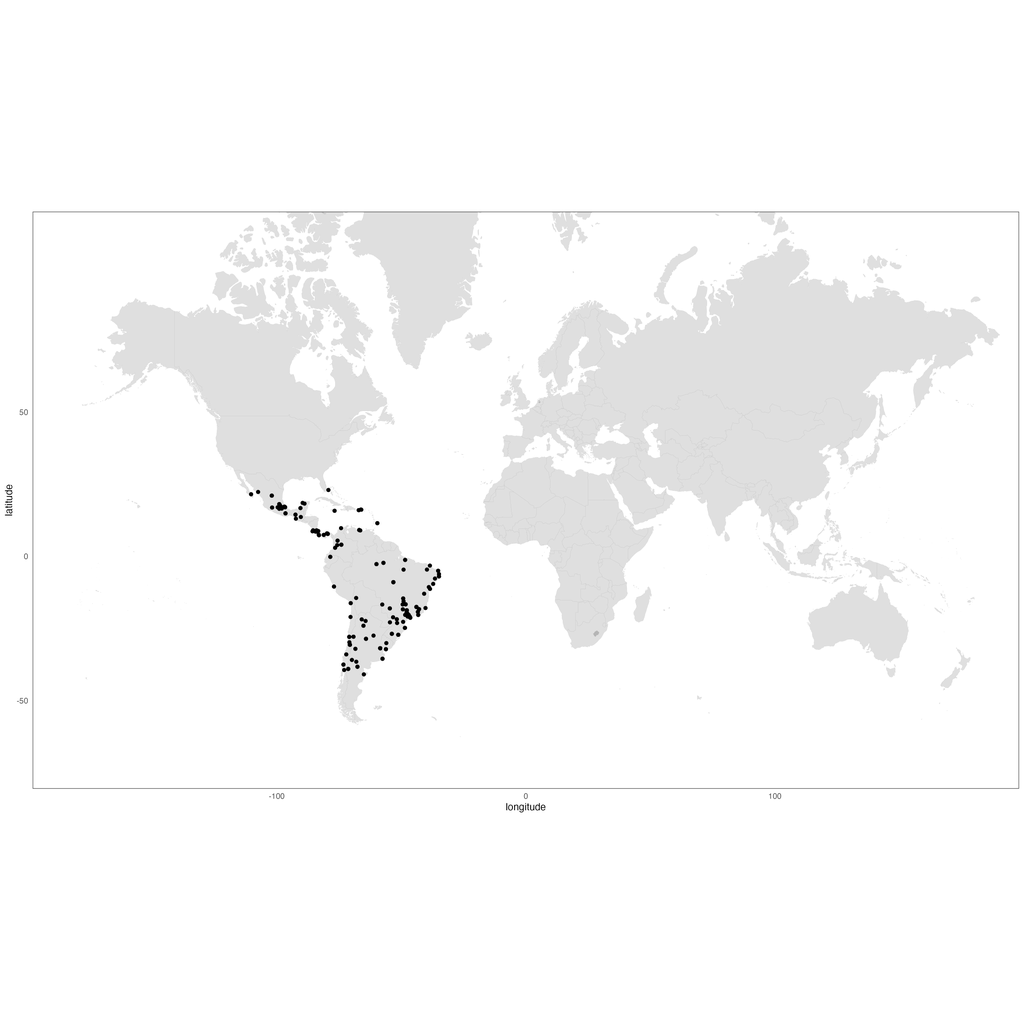

Locations of 1st authors based in Latin America

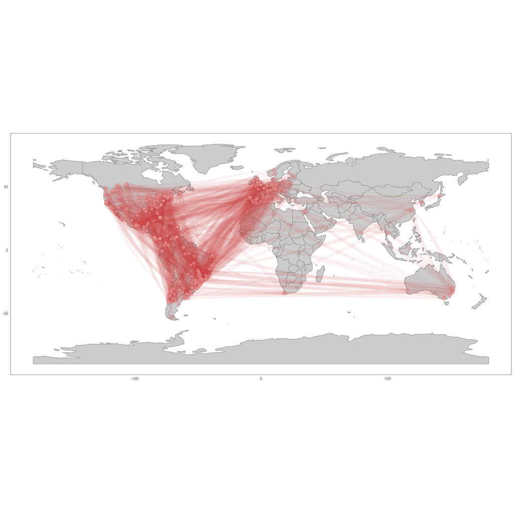

Coauthorship Networks for articles with 1st authors based in Latin America

#### 1st Authors based in the USA

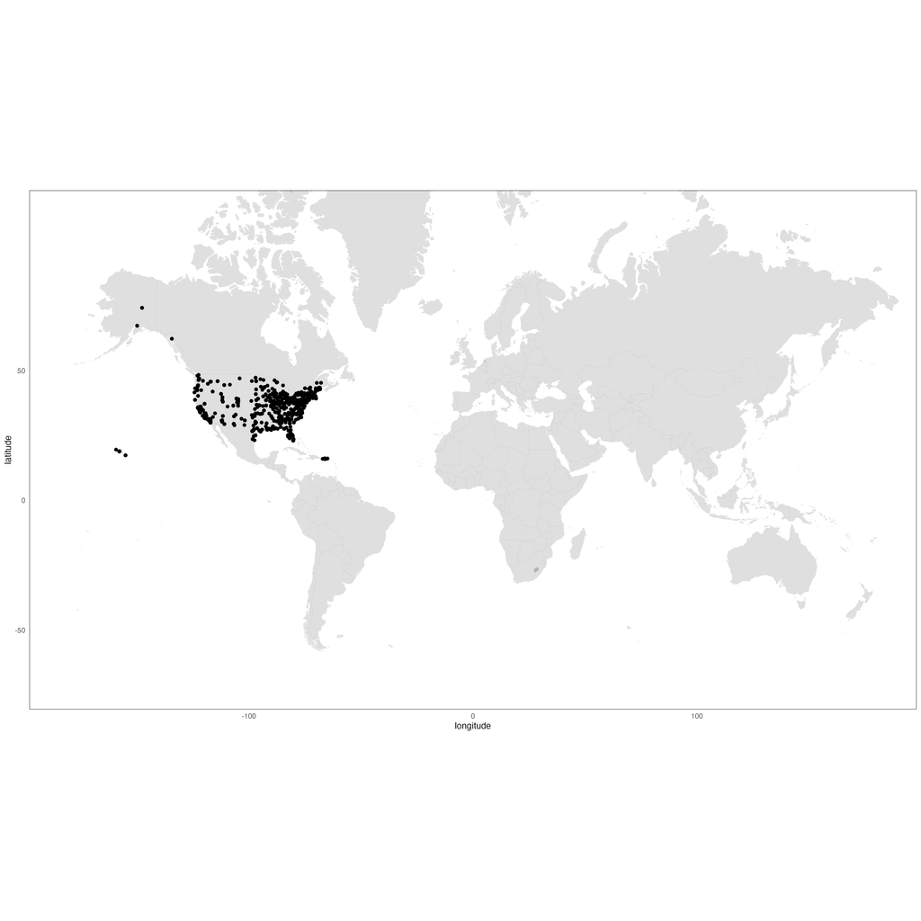

Locations of 1st authors based in USA

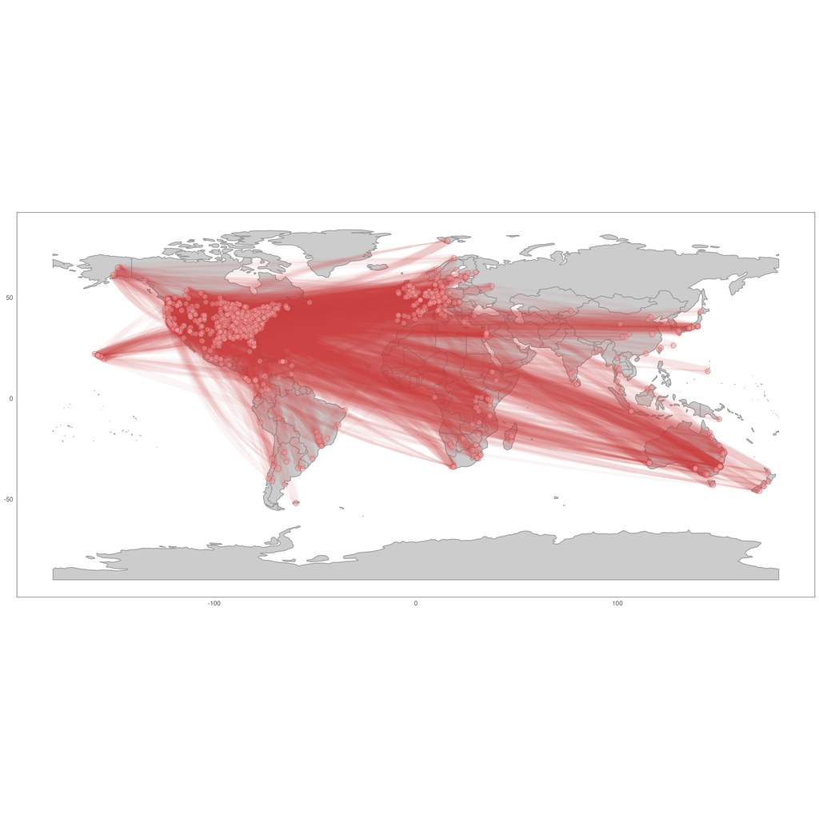

Coauthorship Networks for articles with 1st authors based in USA